# Machine Learning 2019: Feature Selection

Sonali Narang

October 24, 2019

## Feature Selection

In machine learning, feature selection is the process of choosing variables that are useful in predicting the response variable. Selecting the right features in your data can mean the difference between mediocre performance with long training times and great performance with short training times that are less computationally intensive.

Often, data can contain attributes that are highly correlated with each other or not useful in helping predict our response variable. Many methods perform better if such variables are removed. Feature selection is usually imporant to implement during the data pre-processing steps of machine learning.

## The Breast Cancer Dataset

699 Observations, 11 variables Predictor Variable: Class- benign or malignant

```r
data(BreastCancer)
head(BreastCancer)
```

|  | Id | Cl.thickness | Cell.size | Cell.shape | Marg.adhesion | Epith.c.size | Bare.nuclei | Bl.cromatin | Normal.nucleoli | Mitoses | Class |
| --- | --- | --- | --- | --- | --- | --- | --- | --- | --- | --- | --- |
| 1 | 1000025 | 5 | 1 | 1 | 1 | 2 | 1 | 3 | 1 | 1 | benign |
| 2 | 1002945 | 5 | 4 | 4 | 5 | 7 | 10 | 3 | 2 | 1 | benign |
| 3 | 1015425 | 3 | 1 | 1 | 1 | 2 | 2 | 3 | 1 | 1 | benign |
| 4 | 1016277 | 6 | 8 | 8 | 1 | 3 | 4 | 3 | 7 | 1 | benign |
| 5 | 1017023 | 4 | 1 | 1 | 3 | 2 | 1 | 3 | 1 | 1 | benign |
| 6 | 1017122 | 8 | 10 | 10 | 8 | 7 | 10 | 9 | 7 | 1 | malignant |

```r
dim(BreastCancer)
```

```
## [1] 699  11
```

```r
summary(BreastCancer$Class)
```

```
##    benign malignant
##       458       241
```

## Feature Selection Using Filter Methods: Pearson’s Correlation

Filter Methods are generally used as a preprocessing step so the selection of features is independednt of any machine learning algorithms. Features are selected on the basis of their scores in various statistical tests for their correlation with the outcome variable.

Below we will identify attributes that are highly correlated using Pearson’s correlation which is a measure for quantifying linear dependence between X and Y. Ranges between -1 and 1.

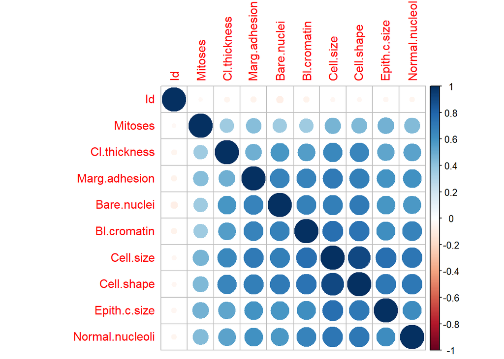

```r
BreastCancer_num = transform(BreastCancer, Id = as.numeric(Id),
                         Cl.thickness = as.numeric(Cl.thickness),
                         Cell.size = as.numeric(Cell.size),
                         Cell.shape = as.numeric(Cell.shape),
                         Marg.adhesion = as.numeric(Marg.adhesion),
                         Epith.c.size = as.numeric(Epith.c.size),
                         Bare.nuclei = as.numeric(Bare.nuclei),
                         Bl.cromatin = as.numeric(Bl.cromatin),
                         Normal.nucleoli = as.numeric(Normal.nucleoli),
                         Mitoses = as.numeric(Mitoses))

BreastCancer_num[is.na(BreastCancer_num)] = 0

#calculate correlation matrix using pearson correlation (others include spearman and kendall)
correlation_matrix = cor(BreastCancer_num[,1:10])

#visualize correlation matrix
library(corrplot)
corrplot(correlation_matrix, order = "hclust")
```

```r
#apply correlation filter of 0.7
highly_correlated <- colnames(BreastCancer[, -1])[findCorrelation(correlation_matrix, cutoff = 0.7, verbose = TRUE)]
```

```
## Compare row 3  and column  4 with corr  0.907
##   Means:  0.631 vs 0.477 so flagging column 3
## Compare row 4  and column  8 with corr  0.736
##   Means:  0.588 vs 0.447 so flagging column 4
## All correlations <= 0.7
```

```r
#which features are highly correlated and can be removed
highly_correlated
```

```
## [1] "Cell.shape"    "Marg.adhesion"
```

## Feature Selection Using Wrapper Methods: Recursive Feature Elimination (RFE)

Wrapper methods are a bit more computationally intensive since we will select features based on a specific machine learning algorith.

The RFE function implements backwards selection of predictors based on predictor importance ranking. The predictors are ranked and the less important ones are sequentially eliminated prior to modeling. The goal is to find a subset of predictors that can be used to produce an accurate model.

```r
data(BreastCancer)
BreastCancer_num = transform(BreastCancer, Id = as.numeric(Id),
                         Cl.thickness = as.numeric(Cl.thickness),
                         Cell.size = as.numeric(Cell.size),
                         Cell.shape = as.numeric(Cell.shape),
                         Marg.adhesion = as.numeric(Marg.adhesion),
                         Epith.c.size = as.numeric(Epith.c.size),
                         Bare.nuclei = as.numeric(Bare.nuclei),
                         Bl.cromatin = as.numeric(Bl.cromatin),
                         Normal.nucleoli = as.numeric(Normal.nucleoli),
                         Mitoses = as.numeric(Mitoses))

BreastCancer_num[is.na(BreastCancer_num)] = 0

#define the control
control = rfeControl(functions = caretFuncs, number = 2)

# run the RFE algorithm
results = rfe(BreastCancer_num[,1:10], BreastCancer_num[,11], sizes = c(2,5,9), rfeControl = control, method = "svmRadial")

results
```

```
##
## Recursive feature selection
##
## Outer resampling method: Bootstrapped (2 reps)
##
## Resampling performance over subset size:
##
##  Variables Accuracy  Kappa AccuracySD  KappaSD Selected
##          2   0.9374 0.8586  0.0028516 0.002413
##          5   0.9526 0.8939  0.0025562 0.005937
##          9   0.9545 0.8993  0.0054893 0.009676        *
##         10   0.9469 0.8827  0.0001426 0.002541
##
## The top 5 variables (out of 9):
##    Cell.size, Cell.shape, Bare.nuclei, Bl.cromatin, Epith.c.size
```

```r
results$variables
```

| benign | malignant | Overall | var | Variables | Resample |
| --- | --- | --- | --- | --- | --- |
| 0.9784631 | 0.9784631 | 0.9784631 | Cell.size | 10 | Resample1 |
| 0.9773534 | 0.9773534 | 0.9773534 | Cell.shape | 10 | Resample1 |
| 0.9501083 | 0.9501083 | 0.9501083 | Bare.nuclei | 10 | Resample1 |
| 0.9494247 | 0.9494247 | 0.9494247 | Bl.cromatin | 10 | Resample1 |
| 0.9315276 | 0.9315276 | 0.9315276 | Epith.c.size | 10 | Resample1 |
| 0.9148778 | 0.9148778 | 0.9148778 | Marg.adhesion | 10 | Resample1 |
| 0.9107942 | 0.9107942 | 0.9107942 | Cl.thickness | 10 | Resample1 |
| 0.8904824 | 0.8904824 | 0.8904824 | Normal.nucleoli | 10 | Resample1 |
| 0.6983949 | 0.6983949 | 0.6983949 | Mitoses | 10 | Resample1 |
| 0.5527103 | 0.5527103 | 0.5527103 | Id | 10 | Resample1 |

[output cut: 42 more lines]

## Feature Selection Using Embedded Methods: Lasso

Least Absolute Shrinkage and Selection Operator (LASSO) regression

```r
set.seed(24)

#convert data
x = x <- as.matrix(BreastCancer_num[,1:10])
y = as.double(as.matrix(ifelse(BreastCancer_num[,11]=='benign', 0, 1)))

#fit Lasso model
cv.lasso <- cv.glmnet(x, y, family='binomial', alpha=1, parallel=TRUE, standardize=TRUE, type.measure='auc')
```

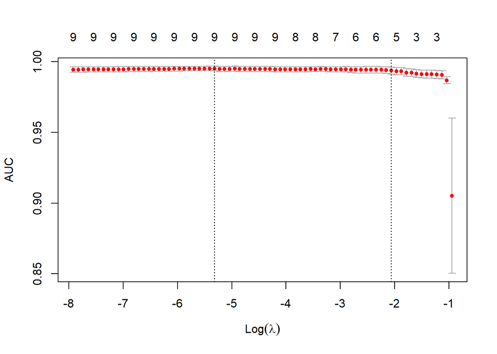

```r
plot(cv.lasso)
```

```r
cat('Min Lambda: ', cv.lasso$lambda.min, '\n 1Sd Lambda: ', cv.lasso$lambda.1se)
```

```
## Min Lambda:  0.0049116
##  1Sd Lambda:  0.1274572
```

```r
df_coef <- round(as.matrix(coef(cv.lasso, s=cv.lasso$lambda.min)), 2)

# See all contributing variables
df_coef[df_coef[, 1] != 0, ]
```

```
##     (Intercept)    Cl.thickness       Cell.size      Cell.shape   Marg.adhesion
##           -7.97            0.44            0.06            0.28            0.16
##    Epith.c.size     Bare.nuclei     Bl.cromatin Normal.nucleoli         Mitoses
##            0.05            0.37            0.33            0.14            0.23
```